# Assignment 1

Daniel Bok (1001049)

Wong Yan Yee (1001212)

Clement Tan (1000948)

02 February 2017

## Question 1A

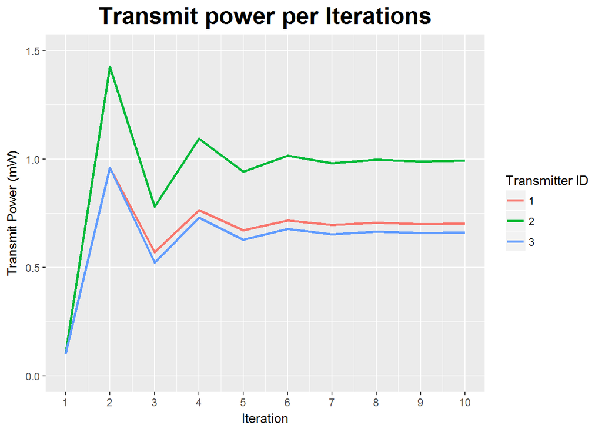

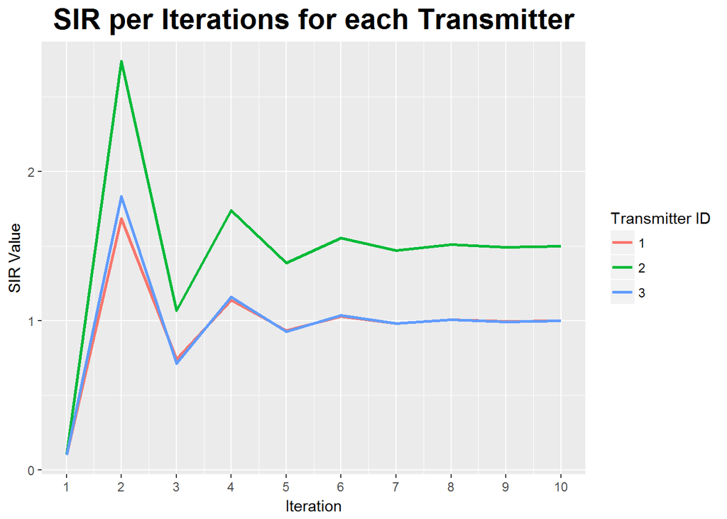

## Question 1B

Following the previous SIR levels for transmitter 1 to 3, the following plots would show the results of adding the transmitter 4 into the system.

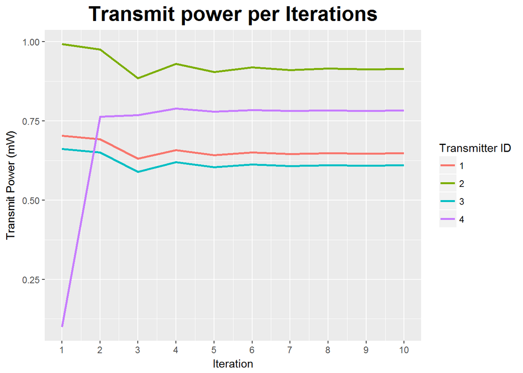

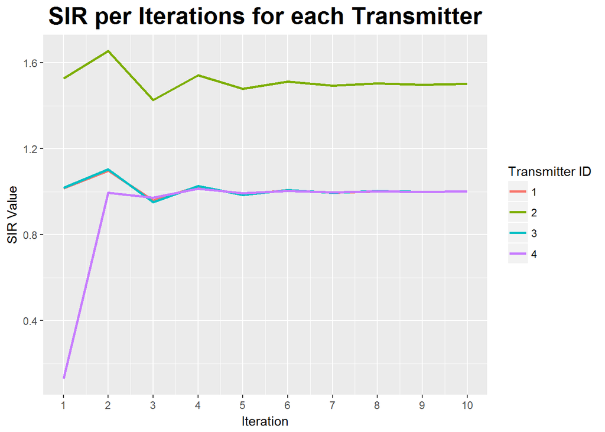

At the new equilibrium, we observe that all transmitters 1-3’s transmission values stabilize at a lower number. We also observe that their SIR values have converged to the target SIR values.

## Question 2

$$D=
\begin{bmatrix}
1 & 0 & 0 \\
0 & 2 & 0 \\
0 & 0 & 1
\end{bmatrix}
F =
\begin{bmatrix}
0 & 0.5 & 0.5 \\
0.5 & 0 & 0.5 \\
0.5 & 0.5 & 0
\end{bmatrix}$$

$$DF =
\begin{bmatrix}
0 & 0.5 & 0.5 \\
1 & 0 & 1 \\
0.5 & 0.5 & 0
\end{bmatrix}$$

Since the magnitude of the largest eigenvalue is greater than 1, as DPC algorithm iterates, the SIR values will diverge and escape to infinity. Thus, there is no feasible solution for the problem.

## Question 3

Given a payoff matrix below
$$\mathbb{P} =
\begin{vmatrix}
2, -2 & 3, -3 \\
3, -3 & 4, -4
\end{vmatrix}$$

There will only be one equilibrium. Alice the row player will always choose row option **b** since that row strongly dominates row option **a**. Similarly Bob the column player will always choose column option **a** since that column strongly dominates column option **b**. As such we will arrive at an equilibrium **(b, a)** or (3, -3).

## Question 4A

$$G =
\begin{bmatrix}
2 & 0.5 \\
0.5 & 2
\end{bmatrix}
\quad
\gamma =
\begin{bmatrix}
4 \\ 2
\end{bmatrix}
\quad
n =
\begin{bmatrix}
0.3 \\ 0.3
\end{bmatrix}$$

$$V =
\begin{bmatrix}
\frac{4 \cdot 0.3}{2} \\
\frac{2 \cdot 0.3}{2}
\end{bmatrix}
=
\begin{bmatrix}
0.6 \\ 0.3
\end{bmatrix}$$

$$(I - DF) =
\begin{bmatrix}
1 & 0 \\
0 & 1
\end{bmatrix}
-
\begin{bmatrix}
4 & 0 \\
0 & 2
\end{bmatrix}$$
$$\begin{bmatrix}
0 & \frac{0.5}{2} \\
\frac{0.5}{2} & 0
\end{bmatrix} \\
=
\begin{bmatrix}
1 & -1 \\
-0.5 & 1
\end{bmatrix}$$

Linear optimization program is thus given by
$$\min \mathbf{1}^TP$$
$$s.t.$$
$$(I - DF) P \geq V$$
$$P \geq \mathbf{0}$$

Therefore, the boundaries are given by

$$p_1 - p_2 \geq 0.6$$
$$-0.5 p_1 + p_2 \geq 0.3$$

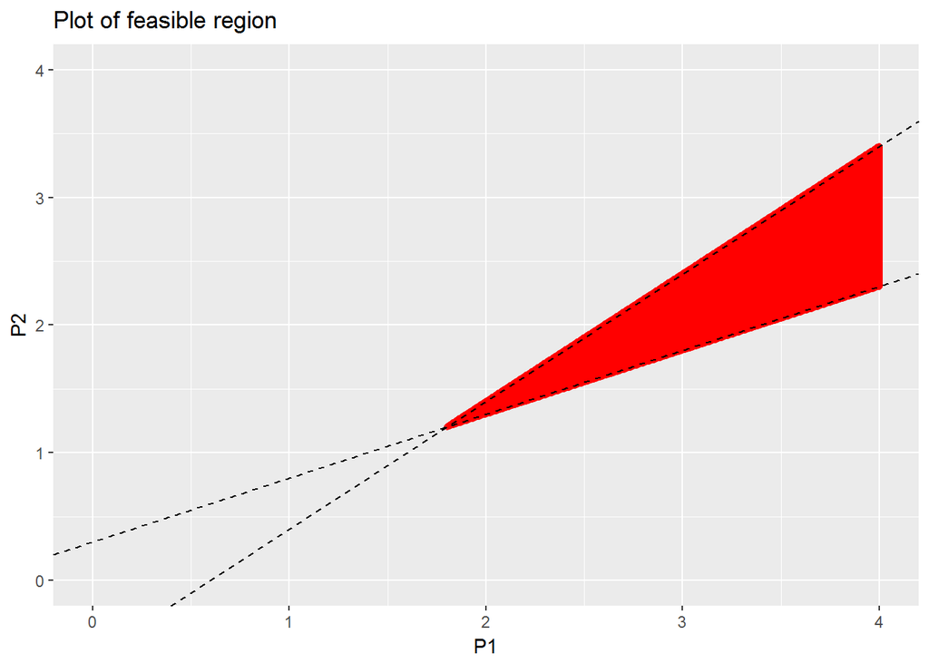

In the above plot, the feasible region (shaded in red) stretches to infinity.

## Question 4B

The payoff matrix (as defined by the SIR) is given by
$$P =
\begin{bmatrix}
2.5, 2.5 & 1.54, 5 & 1.11, 7.5 \\
5, 1.54 & 3.08, 3.08 & 2.22, 4.62 \\
7.5, 1.11 & 4.62, 2.22 & 3.33, 3.33
\end{bmatrix}$$

Note that we denote the rows starting from the top as row 1 and bottom row is 3. Similarly, the column at the leftmost is column 1 and the rightmost is column 3. The row player’s payout is the first index of the tuple and the column player’s payout is the second index of the tuple.

## Question 4C

This is a game where both players want a higher SIR.

For the row player, the row 3 strongly dominates all other rows. That is if the row player choose row 3, he cannot do worse no matter what the column player chooses.

Similarly for the column player, column 3 strongly dominates all other columns regardless of what the row player chooses.

Thus in this instance, the nash equilibrium is achieved when both players transmits at power levels (3, 3). Their corresponding SIR will then be 3.33 each.